# Environmental Trichloroethylene (TCE) Exposure, Social Vulnerability, and Cognitive Difficulty in Pennsylvania

BMIN5030 Final Project

Author

Michael Condiff

## 1 Overview

This project asks whether environmental exposure to trichloroethylene (TCE), an industrial solvent and common groundwater contaminant, is associated with cognitive difficulty across Pennsylvania census tracts after accounting for social vulnerability. I will build a tract-level TCE exposure measure from public environmental monitoring data (EPA Water Quality Portal, Superfund sites, and AirToxScreen) and link it to American Community Survey (ACS) estimates of cognitive difficulty and the CDC Social Vulnerability Index (SVI), then model these relationships with regression and machine learning. I discussed this project with Colleen Morse, who helped me understand limitations of mapping Penn Medicine Biobank data without reidentification, and Joe Romano, who helped me focus on TCE and provided background on SuperFund sites.

It’s possible that I will run a Phewas on PMBB participants by providing TCE exposure levels at specific locations with Colleen Morse. I am still working on this but it’s possible that we’ll get some hits for kidney or other cancers with higher levels of TCE exposure.

GitHub repository: https://github.com/mundiff/BMIN5030_Final_Project

## 2 Introduction

Trichloroethylene (TCE) is a chlorinated solvent that was used widely for metal degreasing, dry cleaning, and manufacturing, and it remains one of the most frequently detected contaminants at hazardous waste sites and in groundwater across the United States . TCE is classified as carcinogenic to humans, with the strongest evidence for kidney cancer, and a growing body of research links it to neurological harm, including Parkinson’s disease (Camp Lejeune as an example). Much of what is known comes from occupational cohorts or single contamination events, so less is known about how lower-level, community-wide environmental exposure relates to neurological and cognitive health in the general population. Pennsylvania, with its long industrial history and many contaminated sites, is a useful setting to study this question. Exposure is also unlikely to be evenly distributed: communities near industrial sites often face other disadvantages, such as poverty, limited health care access, and housing burden, that independently affect health. Separating the effect of TCE from social vulnerability is therefore central to understanding whether TCE contributes to cognitive difficulty at the population level.

## 3 Methods

The unit of analysis is the 2020 census tract in Pennsylvania. The outcome is the percentage of adults aged 18-64 with a cognitive difficulty from the ACS 5-year estimates (2018-2022), which are reported on 2020 tract boundaries. Exposure to TCE is measured three ways: water monitoring results from the EPA Water Quality Portal (2000-2020), distance to Superfund sites with TCE as a contaminant of concern, and modeled air concentrations from EPA’s 2020 AirToxScreen. Social vulnerability is measured with SVI component variables from the ACS, and urbanicity with population density.

```r
library(tidyverse)
library(sf)
library(tigris)
library(tidycensus)
library(dataRetrieval)   # Water Quality Portal access
library(ggspatial)
library(readxl)
library(janitor)
options(tigris_use_cache = TRUE)
```

All downloaded data are saved under `data/raw/` and `data/processed/` the first time they are retrieved, and later renders read the saved copies instead of downloading again. Two small helpers handle this: `cached()` saves the result of a query, and `download_once()` saves a downloaded file. To refresh any source, delete its saved file and render again.

```r
# Run `expr` once and save the result; afterwards read the saved copy
cached <- function(file, expr) {
  if (file.exists(file)) return(readRDS(file))
  dir.create(dirname(file), recursive = TRUE, showWarnings = FALSE)
  out <- expr
  saveRDS(out, file)
  out
}

# Download a file once; a partial download is never left under the final name
download_once <- function(url, file) {
  if (!file.exists(file)) {
    dir.create(dirname(file), recursive = TRUE, showWarnings = FALSE)
    options(timeout = max(1200, getOption("timeout")))
    tmp <- paste0(file, ".part")
    download.file(url, tmp, mode = "wb")
    file.rename(tmp, file)
  }
  file
}

dir.create("data/processed", recursive = TRUE, showWarnings = FALSE)

crs.analysis <- 5070      # CONUS Albers equal-area projection, meters
buffer.m     <- 2000      # "nearby" distance (m)
border.m     <- 10000     # include out-of-state Superfund sites within 10 km of PA
sems.states  <- c("PA", "NJ", "NY", "OH", "WV", "MD", "DE")
tce.pattern  <- regex("trichloroeth(yl)?ene", ignore_case = TRUE)   # excludes trichloroethane
```

### 3.1 Census tract boundaries

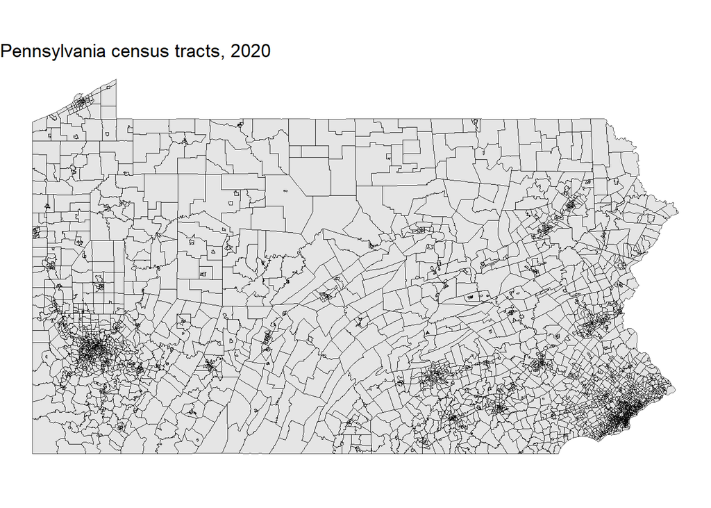

```r
# Cartographic boundaries (water areas such as Lake Erie removed) for maps
pa.tracts <- tracts(state = "PA", year = 2020, cb = TRUE)

# Full TIGER/Line boundaries, projected, for buffers and distances
pa.tracts.tiger <- tracts(state = "PA", year = 2020, cb = FALSE) |>
  st_transform(crs.analysis)

pa.boundary <- states(year = 2020, cb = TRUE) |>
  filter(STUSPS == "PA") |>
  st_transform(crs.analysis)

ggplot() +
  geom_sf(data = pa.tracts, lwd = 0.05) +
  theme_void() +
  ggtitle("Pennsylvania census tracts, 2020")
```

### 3.2 Outcome: cognitive difficulty among adults 18-64 (ACS 2018-2022)

The ACS asks, for each household member age 5 and older, whether “because of a physical, mental, or emotional condition” the person has “serious difficulty concentrating, remembering, or making decisions.” Table B18104 reports the answers by sex and age group. Cognitive difficulty is strongly tied to age: among older adults it largely reflects dementia, and among children it largely reflects developmental conditions. To reduce confounding by a tract’s age structure, the main outcome is the percentage of adults aged 18-64 with a cognitive difficulty: the four “with a cognitive difficulty” counts for ages 18-34 and 35-64 (male and female), divided by the total population in those same four groups. The all-ages percentage is kept for a sensitivity analysis.

```r
acs.vars <- load_variables(2022, "acs5", cache = TRUE)

b18104 <- acs.vars |> filter(str_detect(name, "^B18104_"))

# Numerator: "With a cognitive difficulty" for ages 18-34 and 35-64, both sexes
cog.num.vars <- b18104 |>
  filter(str_detect(label, "(18 to 34|35 to 64) years:!!With a cognitive difficulty"))

# Denominator: the total for each of those four sex-by-age groups
cog.den.vars <- b18104 |>
  filter(str_detect(label, "(18 to 34|35 to 64) years:$"))

# All-ages version (sensitivity analysis)
cog.all.vars <- b18104 |>
  filter(str_detect(label, "With a cognitive difficulty"))

cog.num.vars |> select(name, label)
```

```
# A tibble: 4 × 2
  name       label
  <chr>      <chr>
1 B18104_007 Estimate!!Total:!!Male:!!18 to 34 years:!!With a cognitive difficu…
2 B18104_010 Estimate!!Total:!!Male:!!35 to 64 years:!!With a cognitive difficu…
3 B18104_023 Estimate!!Total:!!Female:!!18 to 34 years:!!With a cognitive diffi…
4 B18104_026 Estimate!!Total:!!Female:!!35 to 64 years:!!With a cognitive diffi…
```

```r
cog.den.vars |> select(name, label)
```

```
# A tibble: 4 × 2
  name       label
  <chr>      <chr>
1 B18104_006 Estimate!!Total:!!Male:!!18 to 34 years:
2 B18104_009 Estimate!!Total:!!Male:!!35 to 64 years:
3 B18104_022 Estimate!!Total:!!Female:!!18 to 34 years:
4 B18104_025 Estimate!!Total:!!Female:!!35 to 64 years:
```

```r
stopifnot(nrow(cog.num.vars) == 4, nrow(cog.den.vars) == 4)

cog.raw <- cached("data/raw/acs_b18104_pa_2022.rds",
  get_acs(geography = "tract",
          state = "PA",
          variables = unique(c(cog.num.vars$name, cog.den.vars$name,
                               cog.all.vars$name, "B18104_001")),
          year = 2022,
          survey = "acs5"))

cog <- cog.raw |>
  group_by(GEOID) |>
  summarize(cog.n      = sum(estimate[variable %in% cog.num.vars$name]),
            pop.1864   = sum(estimate[variable %in% cog.den.vars$name]),
            cog.n.all  = sum(estimate[variable %in% cog.all.vars$name]),
            pop.all    = sum(estimate[variable == "B18104_001"]),
            .groups    = "drop") |>
  mutate(pct.cog     = if_else(pop.1864 > 0, 100 * cog.n / pop.1864, NA_real_),
         pct.cog.all = if_else(pop.all > 0, 100 * cog.n.all / pop.all, NA_real_))

summary(cog$pct.cog)
```

```
   Min. 1st Qu.  Median    Mean 3rd Qu.    Max.    NA's
  0.000   2.881   4.888   5.841   7.567 100.000      41
```

```r
summary(cog$pct.cog.all)
```

```
   Min. 1st Qu.  Median    Mean 3rd Qu.    Max.    NA's
  0.000   3.635   5.524   6.315   7.907  52.632      40
```

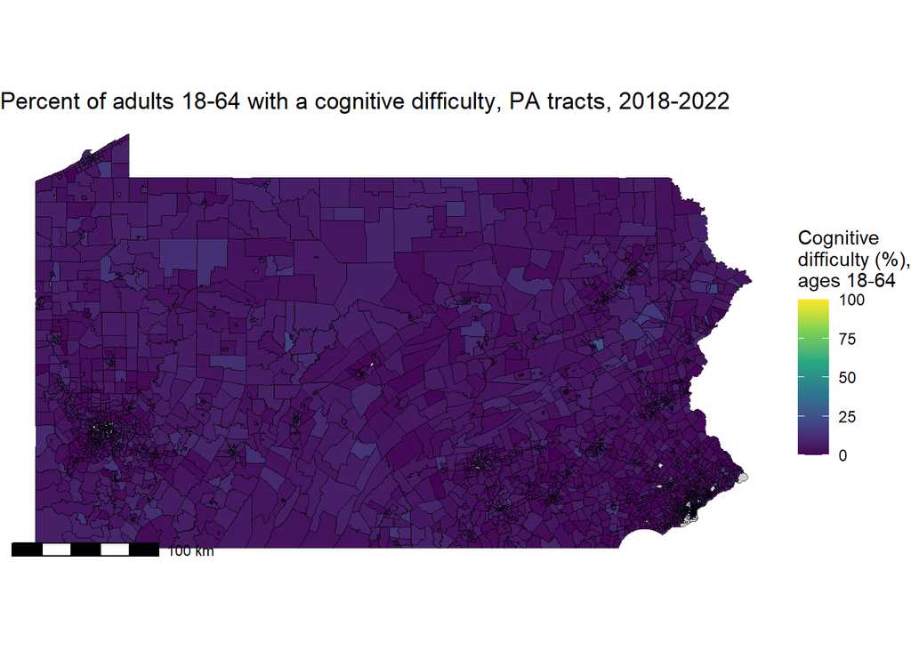

```r
pa.tracts.cog <- pa.tracts |>
  left_join(cog, by = "GEOID")

ggplot() +
  geom_sf(data = pa.tracts.cog, aes(fill = pct.cog), lwd = 0) +
  scale_fill_viridis_c(name = "Cognitive \ndifficulty (%),\nages 18-64", na.value = "grey80") +
  theme_void() +
  ggtitle("Percent of adults 18-64 with a cognitive difficulty, PA tracts, 2018-2022") +
  annotation_scale(location = "bl")
```

### 3.3 Exposure: TCE in water (Water Quality Portal)

I query all TCE results for Pennsylvania from 2000-2020. Most of these are ambient groundwater and surface water samples rather than finished drinking water, so they are treated as a measure of environmental contamination. Monitoring locations come with the results as site information, which I convert to an `sf` object to map.

```r
# Saved with its site information (stored as an attribute) after the first query
tce.raw <- cached("data/raw/wqp_tce_pa_2000_2020.rds",
  readWQPdata(statecode = "US:42",
              characteristicName = "Trichloroethylene",
              startDateLo = "2000-01-01",
              startDateHi = "2020-12-31"))

nrow(tce.raw)
```

```
[1] 1325
```

```r
# How are results reported? (units and detection flags guide the cleaning step)
tce.raw |> count(ResultMeasure.MeasureUnitCode, sort = TRUE)
```

```
  ResultMeasure.MeasureUnitCode   n
1                               753
2                          ug/L 315
3                          ug/l 257
```

```r
tce.raw |> count(ResultDetectionConditionText, sort = TRUE)
```

```
  ResultDetectionConditionText   n
1                 Not Detected 963
2                              318
3                  *Non-detect  43
4      Detected Not Quantified   1
```

```r
# Site information is attached to the results; its coordinate column names
# depend on the dataRetrieval version, so find whichever pair is present
site.info <- attr(tce.raw, "siteInfo")
if (is.null(site.info)) stop("No site information attached to the WQP results.")

lat.col <- intersect(c("dec_lat_va", "LatitudeMeasure", "Location_Latitude"), names(site.info))[1]
lon.col <- intersect(c("dec_lon_va", "LongitudeMeasure", "Location_Longitude"), names(site.info))[1]
if (is.na(lat.col) || is.na(lon.col))
  stop("No latitude/longitude columns found. Site info columns are: ",
       paste(names(site.info), collapse = ", "))

tce.sites <- site.info |>
  mutate(lat = suppressWarnings(as.numeric(.data[[lat.col]])),
         lon = suppressWarnings(as.numeric(.data[[lon.col]]))) |>
  filter(!is.na(lat), !is.na(lon)) |>
  st_as_sf(coords = c("lon", "lat"), crs = 4269) |>
  st_transform(st_crs(pa.tracts))

nrow(tce.sites)
```

```
[1] 602
```

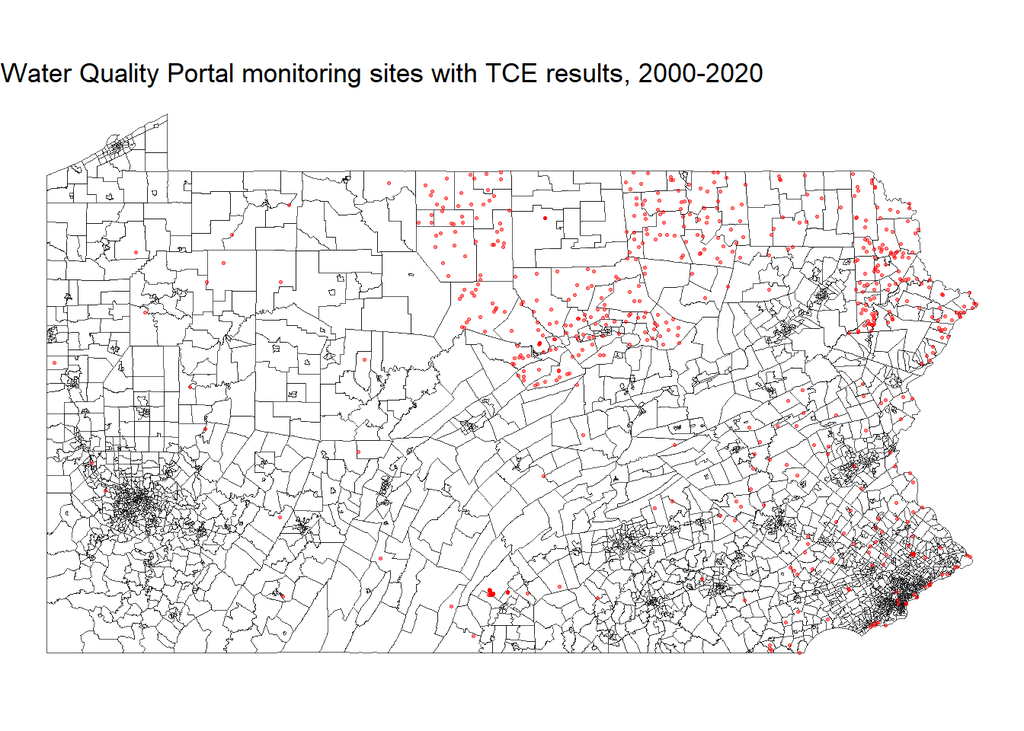

```r
ggplot() +
  geom_sf(data = pa.tracts, lwd = 0.05, fill = "white") +
  geom_sf(data = tce.sites, color = "red", size = 0.6, alpha = 0.5) +
  theme_void() +
  ggtitle("Water Quality Portal monitoring sites with TCE results, 2000-2020")
```

### 3.4 Cleaning the TCE results

The raw Water Quality Portal results need four cleaning steps before they can be used as an exposure measure:

1. **Keep only real water samples.** I drop results from other media (sediment, soil, tissue) and quality control samples such as field blanks and spikes, which do not describe the environment.
2. **Standardize units to µg/L.** Results are reported in several units, so I convert them all to micrograms per liter. Rows with units that cannot be converted to a water concentration (for example, µg/kg) are dropped.
3. **Handle non-detects.** Many samples report that TCE was not detected above a detection limit, rather than a measured value. Treating these as zero would understate exposure, and dropping them would overstate it, so the main analysis substitutes half the detection limit. I also keep two alternative versions (zero and the full detection limit) for a sensitivity check. Results flagged as present but below the quantification limit are treated as detections at the reported limit.
4. **Summarize by monitoring site.** Each site gets its number of samples, whether TCE was ever detected, and its maximum concentration.

```r
# Convert a concentration to µg/L; returns NA for units that are not water concentrations
to.ugl <- function(x, unit) {
  x <- suppressWarnings(as.numeric(x))
  unit <- str_to_lower(str_trim(unit))
  case_when(
    unit %in% c("ug/l", "ppb")  ~ x,
    unit %in% c("mg/l", "ppm")  ~ x * 1000,
    unit %in% c("ng/l", "ppt")  ~ x / 1000,
    TRUE                        ~ NA_real_
  )
}

tce.water <- tce.raw |>
  filter(ActivityMediaName == "Water",
         !str_detect(coalesce(ActivityTypeCode, ""), "Quality Control"))

tce.clean <- tce.water |>
  mutate(
    result.ugl = to.ugl(ResultMeasureValue, ResultMeasure.MeasureUnitCode),
    dl.ugl     = to.ugl(DetectionQuantitationLimitMeasure.MeasureValue,
                        DetectionQuantitationLimitMeasure.MeasureUnitCode),
    condition  = str_to_lower(coalesce(ResultDetectionConditionText, "")),
    # "Not Detected" and "Below ... Limit" are non-detects;
    # "Present Below Quantification Limit" and "Detected Not Quantified" are detections
    nondetect  = str_detect(condition, "not detected|below") &
                 !str_detect(condition, "present"),
    detected   = !nondetect,
    value.ugl  = case_when(
      nondetect                ~ dl.ugl / 2,
      !is.na(result.ugl)       ~ result.ugl,
      TRUE                     ~ dl.ugl        # detected but not quantified
    ),
    value.ugl.nd0 = if_else(nondetect, 0, value.ugl),      # sensitivity: non-detects = 0
    value.ugl.ndl = if_else(nondetect, dl.ugl, value.ugl)  # sensitivity: non-detects = DL
  ) |>
  filter(!is.na(value.ugl)) |>
  # the same sample can be reported more than once (e.g., total and dissolved fractions)
  distinct(MonitoringLocationIdentifier, ActivityStartDate, value.ugl, .keep_all = TRUE)
```

Before summarizing, I check how many rows each step removed, how common non-detects are, and how high the detection limits are. Detection limits matter because a non-detect with a very high limit (well above the EPA drinking water standard of 5 µg/L) carries little information and would inflate the maximum after substitution.

```r
tibble(step = c("Raw results", "Water, non-QC", "Usable value after cleaning"),
       rows = c(nrow(tce.raw), nrow(tce.water), nrow(tce.clean)))
```

```
# A tibble: 3 × 2
  step                         rows
  <chr>                       <int>
1 Raw results                  1325
2 Water, non-QC                1284
3 Usable value after cleaning  1271
```

```r
tce.clean |> count(detected)
```

```
  detected   n
1    FALSE 926
2     TRUE 345
```

```r
tce.clean |>
  filter(nondetect) |>
  summarize(median.dl = median(dl.ugl),
            pct.dl.above.mcl = 100 * mean(dl.ugl > 5))
```

```
  median.dl pct.dl.above.mcl
1       0.5                0
```

```r
summary(tce.clean$value.ugl)
```

```
     Min.   1st Qu.    Median      Mean   3rd Qu.      Max.
    0.007     0.050     0.250    16.711     0.500 14100.000
```

```r
tce.site.summary <- tce.clean |>
  group_by(MonitoringLocationIdentifier) |>
  summarize(n.samples  = n(),
            any.detect = any(detected),
            max.ugl    = max(value.ugl),
            first.year = min(year(ActivityStartDate)),
            last.year  = max(year(ActivityStartDate)))

# Projected CRS (CONUS Albers, meters) so buffers and distances are in real units
tce.sites.5070 <- tce.sites |>
  inner_join(tce.site.summary, by = "MonitoringLocationIdentifier") |>
  st_transform(crs.analysis)

tce.sites.5070 |> st_drop_geometry() |> count(any.detect)
```

```
  any.detect   n
1      FALSE 534
2       TRUE  62
```

### 3.5 Tract-level water exposure

Monitoring sites are points, but the analysis needs one value per tract. For each tract I find all monitoring sites within 2 km of the tract boundary and record the number of sites and samples, whether TCE was detected at any of them, and the maximum concentration. Because sampling clusters near suspected contamination, a tract with no nearby monitoring is coded as missing rather than zero: “no TCE found” and “nobody looked” are different situations. To give every tract a value, I also compute the distance from each tract to the nearest site where TCE was detected.

Buffers and distances use the full TIGER/Line tract boundaries (`pa.tracts.tiger`) because the cartographic boundaries used for maps are simplified, which would distort them.

```r
near <- st_is_within_distance(pa.tracts.tiger, tce.sites.5070, dist = 2000)

tract.tce <- tibble(
  GEOID          = pa.tracts.tiger$GEOID,
  n.sites        = lengths(near),
  n.samples      = map_int(near, \(i) sum(tce.sites.5070$n.samples[i])),
  tce.detect.any = map_int(near, \(i) if (length(i) == 0) NA_integer_
                                      else as.integer(any(tce.sites.5070$any.detect[i]))),
  tce.max.ugl    = map_dbl(near, \(i) if (length(i) == 0) NA_real_
                                      else max(tce.sites.5070$max.ugl[i]))
)

# Distance from each tract to the nearest site with a detection (0 if the site is inside the tract)
detect.sites <- tce.sites.5070 |> filter(any.detect)
nearest <- st_nearest_feature(pa.tracts.tiger, detect.sites)
tract.tce$dist.detect.km <- as.numeric(
  st_distance(pa.tracts.tiger, detect.sites[nearest, ], by_element = TRUE)) / 1000

tract.tce |>
  mutate(status = case_when(n.sites == 0        ~ "Not monitored",
                            tce.detect.any == 1 ~ "TCE detected",
                            TRUE                ~ "Monitored, not detected")) |>
  count(status)
```

```
# A tibble: 3 × 2
  status                      n
  <chr>                   <int>
1 Monitored, not detected   359
2 Not monitored            2811
3 TCE detected              276
```

```r
summary(tract.tce$dist.detect.km)
```

```
   Min. 1st Qu.  Median    Mean 3rd Qu.    Max.
  0.000   7.461  43.436  44.337  70.571 194.298
```

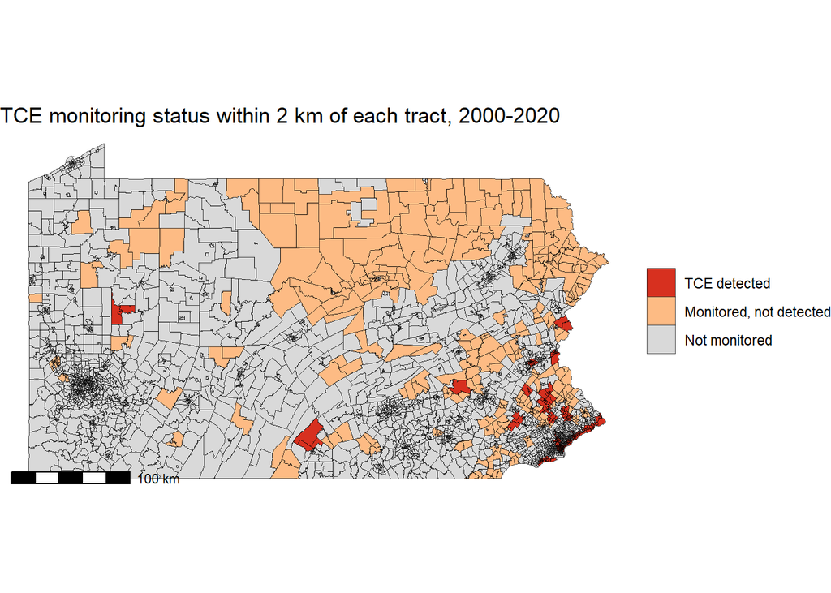

```r
pa.tracts.tce <- pa.tracts |>
  left_join(tract.tce, by = "GEOID") |>
  mutate(status = case_when(n.sites == 0        ~ "Not monitored",
                            tce.detect.any == 1 ~ "TCE detected",
                            TRUE                ~ "Monitored, not detected"),
         status = factor(status, levels = c("TCE detected", "Monitored, not detected",
                                            "Not monitored")))

ggplot() +
  geom_sf(data = pa.tracts.tce, aes(fill = status), lwd = 0) +
  scale_fill_manual(name = NULL,
                    values = c("TCE detected" = "#d7301f",
                               "Monitored, not detected" = "#fdbb84",
                               "Not monitored" = "grey85")) +
  theme_void() +
  ggtitle("TCE monitoring status within 2 km of each tract, 2000-2020") +
  annotation_scale(location = "bl")
```

### 3.6 Exposure: Superfund sites with TCE

The second exposure measure is proximity to Superfund sites where TCE is a contaminant of concern. Site and contaminant records come from EPA’s Superfund Enterprise Management System (SEMS) through the Envirofacts API. The API’s built-in join between the site and contaminant tables fails, so the two tables are pulled separately and joined here on the site ID. Sites in the six neighboring states are included so that tracts near the state border are not treated as far from every site. Each site is located by its recorded coordinate, not its full footprint, and is flagged if TCE was recorded in groundwater, the pathway most relevant to vapor intrusion.

```r
ef.base     <- "https://data.epa.gov/efservice/"
ef.max.rows <- 100000L   # integer, so it pastes into URLs as "100000" rather than "1e+05"

ef_get <- function(url) {
  df <- read_csv(url, col_types = cols(.default = "c"), show_col_types = FALSE)
  if (ncol(df) == 1 && str_detect(names(df)[1], "error"))
    stop("Envirofacts API error for ", url, ": ", names(df)[1])
  if (nrow(df) >= ef.max.rows) warning("Results may be truncated: ", url)
  clean_names(df)
}

# TCE contaminant records for all SEMS sites nationwide
sems.contam.tce <- cached("data/raw/sems_contaminants_tce.rds",
  ef_get(paste0(ef.base, "sems.envirofacts_contaminants/preferred_contaminant_name/",
                "contains/trichloroeth/1:", ef.max.rows, "/CSV"))) |>
  filter(str_detect(preferred_contaminant_name, tce.pattern))   # drops trichloroethane

sems.contam.tce |> count(preferred_contaminant_name)
```

```
# A tibble: 1 × 2
  preferred_contaminant_name     n
  <chr>                      <int>
1 TRICHLOROETHENE             2344
```

```r
sems.contam.tce |> count(media_name, sort = TRUE) |> head(8)
```

```
# A tibble: 8 × 2
  media_name        n
  <chr>         <int>
1 Groundwater    1401
2 Soil            513
3 Surface Water   105
4 Soil Gas         93
5 Sediment         49
6 Air              46
7 Solid Waste      32
8 Leachate         27
```

```r
# Sites in Pennsylvania and neighboring states
sems.sites <- cached("data/raw/sems_sites_pa_region.rds",
  map(sems.states, \(st) ef_get(paste0(ef.base, "sems.envirofacts_site/fk_ref_state_code/",
                                       "equals/", st, "/1:", ef.max.rows, "/CSV"))) |>
    list_rbind())

npl.site.info <- sems.contam.tce |>
  group_by(site_id = fk_site_id) |>
  summarize(media       = paste(sort(unique(media_name)), collapse = "; "),
            groundwater = any(str_detect(media_name, regex("ground", ignore_case = TRUE)),
                              na.rm = TRUE),
            .groups     = "drop")

npl.sites <- sems.sites |>
  distinct(site_id, .keep_all = TRUE) |>
  inner_join(npl.site.info, by = "site_id") |>
  mutate(lat = as.numeric(primary_latitude_decimal_val),
         lon = as.numeric(primary_longitude_decimal_val)) |>
  filter(!is.na(lat), !is.na(lon)) |>
  st_as_sf(coords = c("lon", "lat"), crs = 4326) |>
  st_transform(crs.analysis)

# Keep sites in PA or within 10 km of the state boundary
npl.sites <- npl.sites[lengths(st_is_within_distance(npl.sites, pa.boundary, border.m)) > 0, ]

npl.sites |> st_drop_geometry() |> count(in.pa = fk_ref_state_code == "PA")
```

```
# A tibble: 2 × 2
  in.pa     n
  <lgl> <int>
1 FALSE    16
2 TRUE     76
```

```r
npl.sites |> st_drop_geometry() |> count(npl_status_name, sort = TRUE)
```

```
# A tibble: 4 × 2
  npl_status_name                n
  <chr>                      <int>
1 Currently on the Final NPL    81
2 Deleted from the Final NPL     9
3 Not on the NPL                 1
4 Proposed for NPL               1
```

Almost all of these sites are on, or were deleted from, the National Priorities List (NPL), because contaminant records come from cleanup decision documents. Sites deleted from the NPL after cleanup are kept, since past exposure is relevant to a long-latency outcome.

Distance is measured from each tract’s 2020 population-weighted center (the Census Bureau’s “center of population”) to the nearest site. Measuring from the tract boundary instead would score a large rural tract as 0 km whenever a site falls anywhere inside it, even if most residents live far away. The boundary-based distance is kept for a sensitivity analysis. Tracts with no population use a point inside the tract.

```r
cenpop.file <- download_once(
  "https://www2.census.gov/geo/docs/reference/cenpop2020/tract/CenPop2020_Mean_TR.txt",
  "data/raw/CenPop2020_Mean_TR.txt")

tract.centers <- read_csv(cenpop.file, col_types = cols(.default = "c")) |>
  clean_names() |>
  filter(statefp == "42") |>
  transmute(GEOID      = paste0(statefp, countyfp, tractce),
            center.pop = as.numeric(population),
            lat        = as.numeric(latitude),
            lon        = as.numeric(longitude))

# One point per tract, in the same order as pa.tracts.tiger
pts.info <- pa.tracts.tiger |>
  st_drop_geometry() |>
  select(GEOID) |>
  left_join(tract.centers, by = "GEOID") |>
  mutate(use.center = !is.na(lat) & !is.na(lon) & coalesce(center.pop, 0) > 0)

center.geom <- pts.info |>
  mutate(lat = if_else(use.center, lat, 0), lon = if_else(use.center, lon, 0)) |>
  st_as_sf(coords = c("lon", "lat"), crs = 4326) |>
  st_transform(crs.analysis) |>
  st_geometry()
inside.geom <- st_point_on_surface(st_geometry(pa.tracts.tiger))
center.geom[!pts.info$use.center] <- inside.geom[!pts.info$use.center]

pa.tract.points <- st_sf(GEOID = pts.info$GEOID, use.center = pts.info$use.center,
                         geometry = center.geom)
count(st_drop_geometry(pa.tract.points), use.center)
```

```
  use.center    n
1      FALSE   15
2       TRUE 3431
```

```r
dist_to_nearest_km <- function(from, to) {
  as.numeric(st_distance(from, to[st_nearest_feature(from, to), ], by_element = TRUE)) / 1000
}

gw.sites <- npl.sites |> filter(groundwater)

tract.superfund <- tibble(
  GEOID                = pa.tracts.tiger$GEOID,
  npl.tce.dist.km      = dist_to_nearest_km(pa.tract.points, npl.sites),
  npl.tce.n.2km        = lengths(st_is_within_distance(pa.tract.points, npl.sites, buffer.m)),
  npl.tce.gw.dist.km   = dist_to_nearest_km(pa.tract.points, gw.sites),
  npl.tce.dist.edge.km = dist_to_nearest_km(pa.tracts.tiger, npl.sites)
)

summary(select(tract.superfund, -GEOID))
```

```
 npl.tce.dist.km    npl.tce.n.2km     npl.tce.gw.dist.km npl.tce.dist.edge.km
 Min.   :  0.1374   Min.   :0.00000   Min.   :  0.1374   Min.   :  0.000
 1st Qu.:  7.2472   1st Qu.:0.00000   1st Qu.:  7.4512   1st Qu.:  5.348
 Median : 12.6096   Median :0.00000   Median : 12.7554   Median : 10.835
 Mean   : 18.6439   Mean   :0.03656   Mean   : 19.3529   Mean   : 16.081
 3rd Qu.: 25.0340   3rd Qu.:0.00000   3rd Qu.: 25.6800   3rd Qu.: 21.524
 Max.   :109.3526   Max.   :2.00000   Max.   :109.3526   Max.   :103.099
```

```r
# Population-center vs. boundary distance
tract.superfund |>
  summarize(n.edge.zero   = sum(npl.tce.dist.edge.km == 0),
            n.center.lt2  = sum(npl.tce.dist.km < 2),
            median.change = median(npl.tce.dist.km - npl.tce.dist.edge.km),
            spearman      = cor(npl.tce.dist.km, npl.tce.dist.edge.km, method = "spearman"))
```

```
# A tibble: 1 × 4
  n.edge.zero n.center.lt2 median.change spearman
        <int>        <int>         <dbl>    <dbl>
1          73          114          1.44    0.975
```

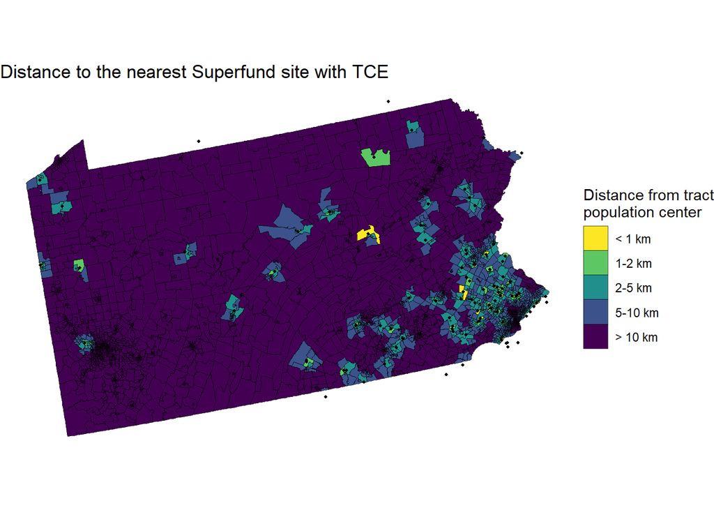

```r
pa.tracts.npl <- pa.tracts |>
  left_join(tract.superfund, by = "GEOID") |>
  mutate(dist.band = cut(npl.tce.dist.km, breaks = c(-Inf, 1, 2, 5, 10, Inf),
                         labels = c("< 1 km", "1-2 km", "2-5 km", "5-10 km", "> 10 km")))

ggplot() +
  geom_sf(data = pa.tracts.npl, aes(fill = dist.band), lwd = 0) +
  geom_sf(data = npl.sites, color = "black", size = 0.8) +
  scale_fill_viridis_d(name = "Distance from tract\npopulation center", direction = -1) +
  coord_sf(xlim = st_bbox(pa.boundary)[c(1, 3)], ylim = st_bbox(pa.boundary)[c(2, 4)],
           crs = crs.analysis) +
  theme_void() +
  ggtitle("Distance to the nearest Superfund site with TCE")
```

### 3.7 Exposure: modeled air concentrations (AirToxScreen 2020)

The third exposure measure is EPA’s 2020 AirToxScreen, which models outdoor air toxics concentrations from emissions inventories. I use the exposure concentration, which adjusts outdoor levels for time spent in different settings, summed across all emission sources. The 2020 results are reported for census blocks, which nest inside 2020 tracts, so each tract’s value is the average of its blocks weighted by block population from the 2020 Census.

```r
airtox.zip <- download_once(
  "https://gaftp.epa.gov/rtrmodeling_public/AirToxScreen/2020/Pollutant%20Summaries/Region3/TRICHLOROETHYLENE_EXPCONC_R3.zip",
  "data/raw/TRICHLOROETHYLENE_EXPCONC_R3.zip")

airtox.csv <- "data/raw/airtox/TRICHLOROETHYLENE_EXPCONC_R3.csv"
if (!file.exists(airtox.csv)) unzip(airtox.zip, exdir = "data/raw/airtox")

# Region 3 file (PA, DE, MD, VA, WV, DC): keep Pennsylvania blocks
airtox <- read_csv(airtox.csv, show_col_types = FALSE, guess_max = 100000) |>
  clean_names() |>
  mutate(block.id = sprintf("%.0f", block)) |>   # 15-digit block FIPS stored as a number
  filter(str_starts(block.id, "42"))

airtox |> count(pollutant_name)
```

```
# A tibble: 1 × 2
  pollutant_name         n
  <chr>              <int>
1 TRICHLOROETHYLENE 275023
```

```r
summary(airtox$total_exposure_conc)
```

```
     Min.   1st Qu.    Median      Mean   3rd Qu.      Max.
 0.000134  0.001315  0.002207  0.005282  0.004924 12.444288
```

```r
# 2020 Census block populations (one request per county the first time, then cached)
block.pop <- cached("data/processed/pa_block_pop_2020.rds", {
  pa.counties <- fips_codes |> filter(state == "PA") |> pull(county_code)
  map(pa.counties, \(cty) get_decennial(geography = "block", variables = "P1_001N",
                                         year = 2020, sumfile = "pl",
                                         state = "PA", county = cty)) |>
    list_rbind() |>
    select(id = GEOID, pop = value)
})

airtox.blocks <- airtox |>
  select(block.id, total = total_exposure_conc, point = pt_stationary_point_exposure_conc) |>
  left_join(block.pop, by = c("block.id" = "id")) |>
  mutate(GEOID = str_sub(block.id, 1, 11), pop = replace_na(pop, 0))

mean(!is.na(match(airtox.blocks$block.id, block.pop$id)))   # share of blocks matched
```

```
[1] 1
```

```r
tract.airtox <- airtox.blocks |>
  group_by(GEOID) |>
  summarize(n.blocks   = n(),
            airtox.pop = sum(pop),
            airtox.tce = if (sum(pop) > 0) weighted.mean(total, pop) else mean(total),
            pct.point  = 100 * sum(point * pop) / sum(total * pop),
            .groups    = "drop")

sum(!pa.tracts.tiger$GEOID %in% tract.airtox$GEOID)   # tracts with no value (unpopulated)
```

```
[1] 15
```

```r
summary(tract.airtox$airtox.tce)
```

```
     Min.   1st Qu.    Median      Mean   3rd Qu.      Max.
0.0005283 0.0016917 0.0030787 0.0066649 0.0072452 1.5832779
```

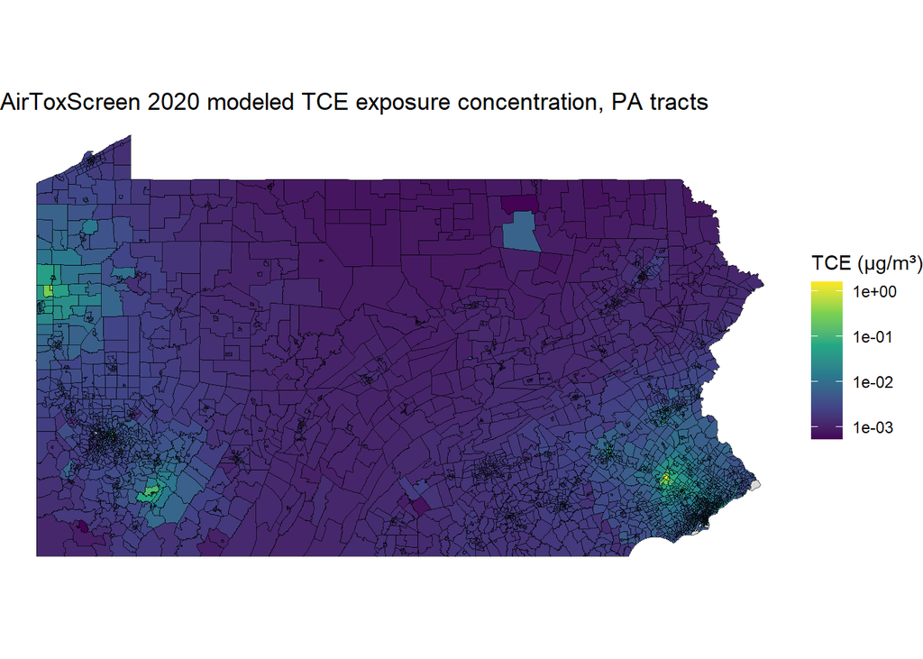

```r
ggplot() +
  geom_sf(data = left_join(pa.tracts, tract.airtox, by = "GEOID"),
          aes(fill = airtox.tce), lwd = 0) +
  scale_fill_viridis_c(name = "TCE (µg/m³)", trans = "log10", na.value = "grey85") +
  theme_void() +
  ggtitle("AirToxScreen 2020 modeled TCE exposure concentration, PA tracts")
```

Modeled concentrations are very right-skewed: the highest tract is several hundred times the statewide median. To see what drives the hotspots, I list the highest tracts with the share of their concentration coming from stationary point sources (industrial facilities), and the Pennsylvania facilities with the largest reported TCE emissions in AirToxScreen’s 2020 facility inventory.

```r
tract.airtox |>
  arrange(desc(airtox.tce)) |>
  select(GEOID, airtox.tce, pct.point, airtox.pop) |>
  head(10)
```

```
# A tibble: 10 × 4
   GEOID       airtox.tce pct.point airtox.pop
   <chr>            <dbl>     <dbl>      <dbl>
 1 42091206400      1.58       99.9       4002
 2 42085032402      0.471     100.0       1641
 3 42129806400      0.370      99.9       2450
 4 42091206300      0.316      99.7       5043
 5 42091206105      0.293      99.8       6187
 6 42085032401      0.288      99.9       1477
 7 42091206104      0.241      99.6       3938
 8 42003120900      0.216      99.5       1545
 9 42091206501      0.196      99.5       4147
10 42011000300      0.140      99.2       2373
```

```r
fac.file <- download_once(
  "https://www.epa.gov/system/files/other-files/2024-05/point_fac_2020_mapapp.xlsx",
  "data/raw/point_fac_2020_mapapp.xlsx")

# One row per facility, one column per pollutant (tons in 2020). The first seven
# columns identify the facility; a label row sits below the file's title row.
fac <- read_excel(fac.file) |> clean_names()
tce.col <- names(fac)[str_detect(names(fac), "^trichloroethylene")][1]

airtox.facilities <- fac |>
  select(1:7, all_of(tce.col)) |>
  setNames(c("eis.facility.id", "facility", "county.fips", "county", "state",
             "lat", "lon", "tce.tons")) |>
  mutate(tce.tons = suppressWarnings(as.numeric(tce.tons))) |>   # drops the label row
  filter(state == "Pennsylvania", tce.tons > 0) |>
  arrange(desc(tce.tons))

airtox.facilities |> select(facility, county, tce.tons) |> head(10)
```

```
# A tibble: 10 × 3
   facility                                         county          tce.tons
   <chr>                                            <chr>              <dbl>
 1 SALEM TUBE INC/GREENVILLE REYNOLDS IND PK        Mercer Co         39.2
 2 VIANT COLLEGEVILLE LLC                           Montgomery Co     31.1
 3 ALLEIMA PRECISION TUBE LLC/SCOTTDALE PLT         Westmoreland Co   15.7
 4 CARPENTER TECH CORP/READING PLT                  Berks Co           2.30
 5 ELECTRO CHEM ENG & MFG CO/EMMAUS                 Lehigh Co          2.28
 6 BROUDY PRINTING INC/PGH                          Allegheny Co       1.19
 7 LORD CORP/SAEGERTOWN                             Crawford Co        0.7
 8 MODEL FINISHING CO/PHILA                         Philadelphia Co    0.62
 9 KEYSTONE SANI LDFL INC/DUNMORE                   Lackawanna Co      0.354
10 COATING & CONVERTING TECH CORP/ADHESIVE COATINGS Philadelphia Co    0.282
```

```r
write_csv(airtox.facilities, "data/processed/airtox_tce_facilities.csv")
```

### 3.8 Combined exposure file

```r
tract.exposure <- tract.superfund |>
  left_join(select(tract.airtox, GEOID, airtox.tce, airtox.pct.point = pct.point), by = "GEOID") |>
  left_join(tract.tce, by = "GEOID")

# Superfund proximity and air concentration capture different sources
cor(tract.exposure$npl.tce.dist.km, tract.exposure$airtox.tce,
    method = "spearman", use = "complete.obs")
```

```
[1] -0.4148971
```

```r
write_csv(tract.exposure, "data/processed/tract_tce_exposure.csv")
```

### 3.9 Social vulnerability and proximity to urban environments (ACS 2018-2022)

Social vulnerability is measured with component variables that follow the CDC SVI definitions, taken directly from the same ACS 2018-2022 data as the outcome so the survey years match. I use the components rather than the SVI composite scores because the SVI Household Characteristics theme includes the percentage of residents with a disability and the percentage aged 65 and older, which overlap with the outcome. The components are the percentage below 150% of the federal poverty line, unemployment rate, percentage of adults 25 and older without a high school diploma, percentage without health insurance, median household income, and percentage of residents who are a racial or ethnic minority (everyone other than non-Hispanic white). Urbanicity is measured as population density (people per square kilometer of land).

```r
ses.vars <- c(pov.tot   = "C17002_001", pov.lt50  = "C17002_002", pov.50_99  = "C17002_003",
              pov.100_124 = "C17002_004", pov.125_149 = "C17002_005",
              lf.civ    = "B23025_003", unemp     = "B23025_005",
              ed.tot    = "B15003_001",
              setNames(sprintf("B15003_%03d", 2:16), paste0("ed.lths", 2:16)),
              hh.income = "B19013_001",
              race.tot  = "B03002_001", nh.white = "B03002_003",
              pop.total = "B01003_001")

ses.raw <- cached("data/raw/acs_ses_pa_2022.rds",
  get_acs(geography = "tract", state = "PA", variables = ses.vars,
          year = 2022, survey = "acs5", output = "wide"))

# Percent uninsured comes from a subject table, so it is pulled separately
uninsured <- cached("data/raw/acs_uninsured_pa_2022.rds",
  get_acs(geography = "tract", state = "PA",
          variables = c(pct.uninsured = "S2701_C05_001"),
          year = 2022, survey = "acs5")) |>
  select(GEOID, pct.uninsured = estimate)

ses <- ses.raw |>
  transmute(GEOID,
            pct.pov150   = 100 * (pov.lt50E + pov.50_99E + pov.100_124E + pov.125_149E) / pov.totE,
            pct.unemp    = 100 * unempE / lf.civE,
            pct.nohs     = 100 * rowSums(pick(matches("^ed\\.lths\\d+E$"))) / ed.totE,
            hh.income    = hh.incomeE,
            pct.minority = 100 * (1 - nh.whiteE / race.totE),
            pop.total    = pop.totalE) |>
  mutate(across(where(is.double), \(x) if_else(is.finite(x), x, NA_real_))) |>
  left_join(uninsured, by = "GEOID")

# Population density from land area of the 2020 tracts
density <- pa.tracts |>
  st_drop_geometry() |>
  transmute(GEOID, land.km2 = ALAND / 1e6)

ses <- ses |>
  left_join(density, by = "GEOID") |>
  mutate(pop.density = if_else(land.km2 > 0, pop.total / land.km2, NA_real_))

summary(select(ses, -GEOID))
```

```
   pct.pov150        pct.unemp         pct.nohs        hh.income
 Min.   :  0.000   Min.   : 0.000   Min.   : 0.000   Min.   : 11558
 1st Qu.:  9.622   1st Qu.: 2.771   1st Qu.: 3.826   1st Qu.: 55924
 Median : 16.731   Median : 4.563   Median : 6.873   Median : 70188
 Mean   : 20.303   Mean   : 5.689   Mean   : 8.584   Mean   : 77527
 3rd Qu.: 26.440   3rd Qu.: 7.435   3rd Qu.:11.269   3rd Qu.: 93287
 Max.   :100.000   Max.   :36.052   Max.   :64.103   Max.   :250001
 NA's   :41        NA's   :41       NA's   :33       NA's   :63
  pct.minority       pop.total     pct.uninsured       land.km2
 Min.   :  0.000   Min.   :    0   Min.   : 0.000   Min.   :   0.0722
 1st Qu.:  7.045   1st Qu.: 2619   1st Qu.: 2.400   1st Qu.:   1.3198
 Median : 15.305   Median : 3668   Median : 4.300   Median :   4.1822
 Mean   : 25.394   Mean   : 3769   Mean   : 5.533   Mean   :  33.6377
 3rd Qu.: 33.863   3rd Qu.: 4802   3rd Qu.: 7.000   3rd Qu.:  28.5796
 Max.   :100.000   Max.   :10323   Max.   :54.800   Max.   :1024.4017
 NA's   :32                        NA's   :40       NA's   :1
  pop.density
 Min.   :    0.0
 1st Qu.:  122.9
 Median :  816.1
 Mean   : 1925.0
 3rd Qu.: 2144.7
 Max.   :35743.5
 NA's   :1
```

### 3.10 Analytic dataset

All sources are joined into one table with one row per tract. Exposure variables are prepared as follows:

- **Water monitoring status** has three levels. The reference level is “Monitored, not detected,” so that tracts where TCE was detected are compared with tracts that were also sampled.
- **Distances** to the nearest water detection and the nearest TCE Superfund site are log-transformed, and the Superfund distance is also grouped into bands (under 5 km, 5-10 km, over 10 km).
- **AirToxScreen concentration** is very right-skewed, so it is log-transformed, and tracts in the top 5% are flagged as high-exposure tracts.

Tracts are excluded if they have fewer than 200 residents aged 18-64 (their ACS estimates are too unstable) or are missing the outcome or a covariate.

```r
analytic.all <- tibble(GEOID = pa.tracts$GEOID) |>
  left_join(cog, by = "GEOID") |>
  left_join(ses, by = "GEOID") |>
  left_join(tract.exposure |>
              rename(water.n.sites    = n.sites,
                     water.n.samples  = n.samples,
                     water.detect.any = tce.detect.any,
                     water.max.ugl    = tce.max.ugl,
                     water.dist.km    = dist.detect.km),
            by = "GEOID") |>
  mutate(
    water.status = case_when(water.n.sites == 0      ~ "Not monitored",
                             water.detect.any == 1   ~ "TCE detected",
                             TRUE                    ~ "Monitored, not detected"),
    water.status = factor(water.status,
                          levels = c("Monitored, not detected", "TCE detected", "Not monitored")),
    log.water.dist = log10(water.dist.km + 0.1),
    log.npl.dist   = log10(npl.tce.dist.km),
    npl.dist.band  = cut(npl.tce.dist.km, breaks = c(0, 5, 10, Inf),
                         labels = c("< 5 km", "5-10 km", "> 10 km"), include.lowest = TRUE),
    npl.dist.band  = fct_relevel(npl.dist.band, "> 10 km"),
    log.airtox     = log10(airtox.tce),
    airtox.high    = as.integer(airtox.tce >= quantile(airtox.tce, 0.95, na.rm = TRUE)),
    log.density    = log10(pop.density + 1),
    income.10k     = hh.income / 10000
  )

# Exclusions, reported step by step
model.vars <- c("pct.cog", "water.status", "log.npl.dist", "log.airtox",
                "pct.pov150", "pct.unemp", "pct.nohs", "pct.uninsured",
                "income.10k", "pct.minority", "log.density")

analytic <- analytic.all |>
  filter(pop.1864 >= 200) |>
  drop_na(all_of(model.vars))

tibble(step = c("All 2020 PA tracts",
                "200+ residents aged 18-64",
                "Complete outcome, exposure, and covariate data"),
       tracts = c(nrow(analytic.all),
                  sum(analytic.all$pop.1864 >= 200, na.rm = TRUE),
                  nrow(analytic)))
```

```
# A tibble: 3 × 2
  step                                           tracts
  <chr>                                           <int>
1 All 2020 PA tracts                               3445
2 200+ residents aged 18-64                        3393
3 Complete outcome, exposure, and covariate data   3378
```

```r
# Which variables cause the most missingness among eligible tracts?
analytic.all |>
  filter(pop.1864 >= 200) |>
  summarize(across(all_of(model.vars), \(x) sum(is.na(x)))) |>
  pivot_longer(everything(), names_to = "variable", values_to = "n.missing") |>
  filter(n.missing > 0)
```

```
# A tibble: 3 × 2
  variable   n.missing
  <chr>          <int>
1 pct.pov150         1
2 pct.nohs           1
3 income.10k        15
```

```r
analytic |> count(water.status)
```

```
# A tibble: 3 × 2
  water.status                n
  <fct>                   <int>
1 Monitored, not detected   356
2 TCE detected              266
3 Not monitored            2756
```

```r
analytic |> count(npl.dist.band)
```

```
# A tibble: 3 × 2
  npl.dist.band     n
  <fct>         <int>
1 > 10 km        2074
2 < 5 km          496
3 5-10 km         808
```

```r
write_csv(analytic, "data/processed/analytic_tracts.csv")
```

## 4 Results

```r
library(gtsummary)   # Table 1
library(sandwich)    # robust standard errors
library(lmtest)
library(broom)
```

### 4.1 Table 1: tract characteristics by TCE exposure

Table 1 compares tracts across water monitoring status, and Table 2 across distance to the nearest TCE Superfund site. Values are medians with interquartile ranges, and p-values are from Kruskal-Wallis tests. These comparisons show whether more-exposed tracts differ systematically in social vulnerability and urbanicity, which would make those characteristics potential confounders.

```r
table1.labels <- list(
  pct.cog         ~ "Cognitive difficulty, ages 18-64 (%)",
  pct.cog.all     ~ "Cognitive difficulty, all ages (%)",
  airtox.tce      ~ "AirToxScreen TCE (µg/m³)",
  npl.tce.dist.km ~ "Distance to TCE Superfund site (km)",
  pct.pov150      ~ "Below 150% of poverty line (%)",
  pct.unemp       ~ "Unemployed (%)",
  pct.nohs        ~ "No high school diploma, age 25+ (%)",
  pct.uninsured   ~ "Uninsured (%)",
  hh.income       ~ "Median household income ($)",
  pct.minority    ~ "Racial or ethnic minority (%)",
  pop.density     ~ "Population density (per km²)",
  pop.1864        ~ "Residents aged 18-64"
)

table1.vars <- map_chr(table1.labels, \(f) as.character(f[[2]]))

make_table1 <- function(data, by, caption) {
  data |>
    select(all_of(c(by, table1.vars))) |>
    tbl_summary(by = all_of(by),
                label = table1.labels,
                statistic = all_continuous() ~ "{median} ({p25}, {p75})",
                digits = list(all_continuous() ~ 1, airtox.tce ~ 4)) |>
    add_overall() |>
    add_p(test = all_continuous() ~ "kruskal.test") |>
    modify_caption(caption)
}

make_table1(analytic, "water.status",
            "**Table 1.** Tract characteristics by water monitoring status (TCE within 2 km)")
```

**Table 1.** Tract characteristics by water monitoring status (TCE within 2 km)

| **Characteristic** | **Overall** N = 3,378<sup>1</sup> | **Monitored, not detected** N = 356<sup>1</sup> | **TCE detected** N = 266<sup>1</sup> | **Not monitored** N = 2,756<sup>1</sup> | **p-value**<sup>2</sup> |
| --- | --- | --- | --- | --- | --- |
| Cognitive difficulty, ages 18-64 (%) | 4.9 (2.9, 7.5) | 4.4 (2.6, 6.3) | 4.1 (2.4, 7.5) | 5.1 (3.0, 7.7) | <0.001 |
| Cognitive difficulty, all ages (%) | 5.5 (3.6, 7.9) | 4.8 (3.3, 6.5) | 5.0 (3.3, 8.1) | 5.7 (3.7, 8.1) | <0.001 |
| AirToxScreen TCE (µg/m³) | 0.0031 (0.0017, 0.0072) | 0.0018 (0.0011, 0.0046) | 0.0087 (0.0071, 0.0101) | 0.0029 (0.0017, 0.0066) | <0.001 |
| Distance to TCE Superfund site (km) | 12.6 (7.2, 25.5) | 13.6 (6.1, 23.5) | 7.1 (3.8, 11.0) | 13.7 (8.0, 27.3) | <0.001 |
| Below 150% of poverty line (%) | 16.7 (9.6, 26.2) | 14.1 (8.1, 20.7) | 17.6 (10.0, 35.4) | 16.9 (9.9, 26.8) | <0.001 |
| Unemployed (%) | 4.6 (2.8, 7.4) | 4.1 (2.8, 6.1) | 5.5 (3.2, 9.0) | 4.6 (2.8, 7.5) | <0.001 |
| No high school diploma, age 25+ (%) | 6.9 (3.8, 11.1) | 7.2 (4.3, 10.6) | 7.6 (3.3, 14.2) | 6.8 (3.8, 11.0) | 0.3 |
| Uninsured (%) | 4.3 (2.4, 7.0) | 4.0 (2.6, 7.1) | 4.5 (2.5, 7.5) | 4.3 (2.4, 7.0) | 0.6 |
| Median household income ($) | 70,203.0 (55,938.0, 93,373.0) | 76,028.5 (62,647.5, 102,402.0) | 77,827.0 (53,355.0, 102,969.0) | 69,503.0 (54,548.5, 91,287.5) | <0.001 |
| Racial or ethnic minority (%) | 15.2 (7.0, 33.3) | 8.9 (4.9, 17.0) | 33.4 (20.2, 65.3) | 15.2 (6.9, 33.2) | <0.001 |
| Population density (per km²) | 838.4 (130.4, 2,154.0) | 77.9 (25.3, 366.4) | 3,134.0 (1,334.4, 8,465.1) | 894.6 (165.6, 2,116.9) | <0.001 |
| Residents aged 18-64 | 2,184.0 (1,583.0, 2,867.0) | 2,094.5 (1,481.0, 2,776.5) | 2,450.0 (1,786.0, 3,133.0) | 2,179.0 (1,583.0, 2,854.5) | <0.001 |

<sup>1</sup> Median (Q1, Q3)  
<sup>2</sup> Kruskal-Wallis rank sum test

```r
make_table1(analytic, "npl.dist.band",
            "**Table 2.** Tract characteristics by distance to the nearest TCE Superfund site")
```

**Table 2.** Tract characteristics by distance to the nearest TCE Superfund site

| **Characteristic** | **Overall** N = 3,378<sup>1</sup> | **> 10 km** N = 2,074<sup>1</sup> | **< 5 km** N = 496<sup>1</sup> | **5-10 km** N = 808<sup>1</sup> | **p-value**<sup>2</sup> |
| --- | --- | --- | --- | --- | --- |
| Cognitive difficulty, ages 18-64 (%) | 4.9 (2.9, 7.5) | 5.2 (3.2, 7.7) | 4.1 (2.4, 6.7) | 4.5 (2.5, 7.4) | <0.001 |
| Cognitive difficulty, all ages (%) | 5.5 (3.6, 7.9) | 5.8 (3.9, 8.0) | 4.9 (3.2, 7.2) | 5.1 (3.3, 8.1) | <0.001 |
| AirToxScreen TCE (µg/m³) | 0.0031 (0.0017, 0.0072) | 0.0024 (0.0014, 0.0041) | 0.0067 (0.0028, 0.0108) | 0.0062 (0.0025, 0.0084) | <0.001 |
| Distance to TCE Superfund site (km) | 12.6 (7.2, 25.5) | 21.6 (13.7, 33.5) | 3.3 (2.3, 4.2) | 7.6 (6.4, 8.8) | <0.001 |
| Below 150% of poverty line (%) | 16.7 (9.6, 26.2) | 17.9 (11.4, 26.5) | 12.7 (7.0, 23.5) | 14.9 (7.8, 28.4) | <0.001 |
| Unemployed (%) | 4.6 (2.8, 7.4) | 4.6 (2.8, 7.3) | 4.2 (2.8, 6.6) | 4.8 (2.7, 7.9) | 0.067 |
| No high school diploma, age 25+ (%) | 6.9 (3.8, 11.1) | 7.1 (4.1, 11.1) | 6.2 (3.5, 10.6) | 6.6 (3.4, 11.5) | 0.011 |
| Uninsured (%) | 4.3 (2.4, 7.0) | 4.3 (2.5, 6.9) | 3.9 (2.0, 6.6) | 4.2 (2.4, 7.8) | 0.020 |
| Median household income ($) | 70,203.0 (55,938.0, 93,373.0) | 66,471.0 (54,238.0, 83,657.0) | 83,920.0 (62,300.5, 111,233.5) | 78,834.0 (56,564.5, 105,074.5) | <0.001 |
| Racial or ethnic minority (%) | 15.2 (7.0, 33.3) | 10.8 (5.3, 26.7) | 20.6 (12.1, 34.9) | 22.1 (12.2, 48.0) | <0.001 |
| Population density (per km²) | 838.4 (130.4, 2,154.0) | 559.6 (68.5, 1,763.6) | 1,101.7 (452.5, 2,094.6) | 1,341.3 (433.9, 3,380.5) | <0.001 |
| Residents aged 18-64 | 2,184.0 (1,583.0, 2,867.0) | 2,045.5 (1,498.0, 2,712.0) | 2,384.0 (1,724.0, 3,053.5) | 2,454.5 (1,852.5, 3,180.0) | <0.001 |

<sup>1</sup> Median (Q1, Q3)  
<sup>2</sup> Kruskal-Wallis rank sum test

### 4.2 Regression models

Each exposure is modeled separately in three nested linear regressions of the percentage of adults 18-64 with a cognitive difficulty:

1. **Crude:** the exposure alone.
2. **+ Social vulnerability:** adding poverty, unemployment, no high school diploma, uninsured, median household income (per $10,000), and percent minority.
3. **+ Urbanicity:** adding log population density.

Models are weighted by the number of residents aged 18-64, because estimates from larger tracts are more precise, and use heteroskedasticity-robust (HC1) standard errors. Comparing the exposure coefficient across the three models shows how much of any crude association is explained by social vulnerability and urbanicity. A final model includes all three exposures together.

How to read the coefficients:

- **Water monitoring status:** the difference in percentage points compared with tracts that were monitored but had no detection.
- **Superfund distance (log10 km):** the change in percentage points for each 10-fold increase in distance. A negative value means tracts closer to sites have more cognitive difficulty.
- **AirToxScreen concentration (log10 µg/m³):** the change in percentage points for each 10-fold increase in modeled TCE.

```r
ses.terms <- "pct.pov150 + pct.unemp + pct.nohs + pct.uninsured + income.10k + pct.minority"

exposures <- c("Water monitoring status"  = "water.status",
               "Superfund distance"       = "log.npl.dist",
               "AirToxScreen air TCE"     = "log.airtox")

model.formulas <- function(expo) {
  c("1. Crude"                    = paste("pct.cog ~", expo),
    "2. + Social vulnerability"   = paste("pct.cog ~", expo, "+", ses.terms),
    "3. + Urbanicity"             = paste("pct.cog ~", expo, "+", ses.terms, "+ log.density"))
}

fit_robust <- function(formula) {
  m <- lm(as.formula(formula), data = analytic, weights = pop.1864)
  coeftest(m, vcov = vcovHC(m, type = "HC1")) |>
    tidy(conf.int = TRUE) |>
    mutate(adj.r2 = summary(m)$adj.r.squared)
}

nested.results <- imap(exposures, \(expo, expo.name) {
  imap(model.formulas(expo), \(f, model.name) {
    fit_robust(f) |> mutate(model = model.name)
  }) |>
    list_rbind() |>
    mutate(exposure = expo.name)
}) |>
  list_rbind() |>
  filter(str_detect(term, "^water.status|^log.npl.dist|^log.airtox"))

nested.results |>
  transmute(exposure, model,
            term = str_remove(term, "^water.status"),
            estimate = round(estimate, 3),
            ci = sprintf("(%.3f, %.3f)", conf.low, conf.high),
            p.value = signif(p.value, 2),
            adj.r2 = round(adj.r2, 3)) |>
  knitr::kable(col.names = c("Exposure", "Model", "Term", "Estimate", "95% CI",
                             "p-value", "Adj. R²"))
```

| Exposure | Model | Term | Estimate | 95% CI | p-value | Adj. R² |
| --- | --- | --- | --- | --- | --- | --- |
| Water monitoring status | 1. Crude | TCE detected | 0.970 | (0.323, 1.617) | 0.0033 | 0.006 |
| Water monitoring status | 1. Crude | Not monitored | 1.072 | (0.725, 1.419) | 0.0000 | 0.006 |
| Water monitoring status | 2. + Social vulnerability | TCE detected | -0.451 | (-0.950, 0.047) | 0.0760 | 0.369 |
| Water monitoring status | 2. + Social vulnerability | Not monitored | 0.228 | (-0.071, 0.527) | 0.1300 | 0.369 |
| Water monitoring status | 3. + Urbanicity | TCE detected | -0.508 | (-1.033, 0.017) | 0.0580 | 0.369 |
| Water monitoring status | 3. + Urbanicity | Not monitored | 0.193 | (-0.114, 0.500) | 0.2200 | 0.369 |
| Superfund distance | 1. Crude | log.npl.dist | 0.955 | (0.650, 1.260) | 0.0000 | 0.009 |
| Superfund distance | 2. + Social vulnerability | log.npl.dist | 0.400 | (0.103, 0.697) | 0.0083 | 0.368 |
| Superfund distance | 3. + Urbanicity | log.npl.dist | 0.445 | (0.139, 0.751) | 0.0044 | 0.368 |
| AirToxScreen air TCE | 1. Crude | log.airtox | -0.113 | (-0.454, 0.228) | 0.5200 | 0.000 |
| AirToxScreen air TCE | 2. + Social vulnerability | log.airtox | 0.051 | (-0.256, 0.358) | 0.7500 | 0.367 |
| AirToxScreen air TCE | 3. + Urbanicity | log.airtox | 0.030 | (-0.289, 0.350) | 0.8500 | 0.367 |

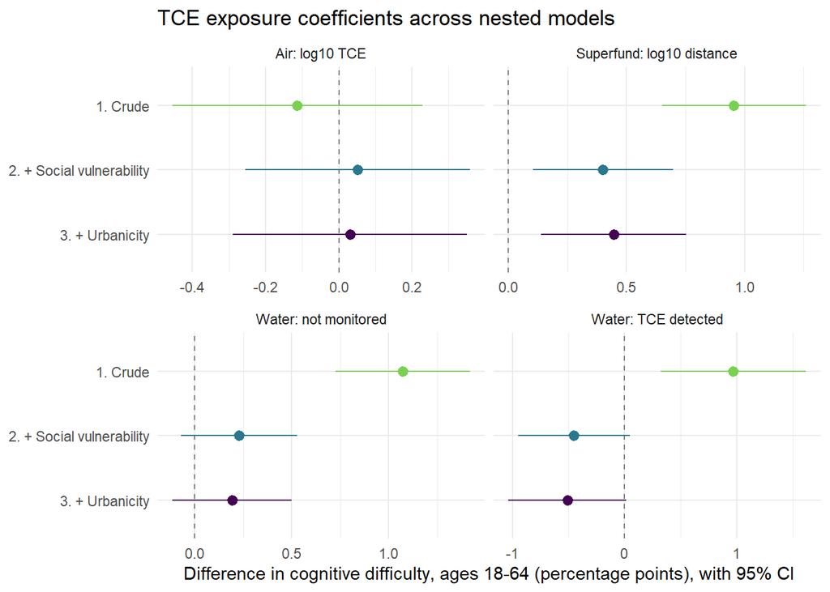

```r
nested.results |>
  mutate(term = case_when(term == "water.statusTCE detected"  ~ "Water: TCE detected",
                          term == "water.statusNot monitored" ~ "Water: not monitored",
                          term == "log.npl.dist"              ~ "Superfund: log10 distance",
                          term == "log.airtox"                ~ "Air: log10 TCE"),
         model = fct_rev(factor(model))) |>
  ggplot(aes(x = estimate, y = model, xmin = conf.low, xmax = conf.high, color = model)) +
  geom_vline(xintercept = 0, linetype = "dashed", color = "grey50") +
  geom_pointrange() +
  facet_wrap(~ term, scales = "free_x", ncol = 2) +
  scale_color_viridis_d(end = 0.8, guide = "none") +
  labs(x = "Difference in cognitive difficulty, ages 18-64 (percentage points), with 95% CI",
       y = NULL,
       title = "TCE exposure coefficients across nested models") +
  theme_minimal()
```

```r
full.formula <- paste("pct.cog ~ water.status + log.npl.dist + log.airtox +",
                      ses.terms, "+ log.density")
m.full <- lm(as.formula(full.formula), data = analytic, weights = pop.1864)

coeftest(m.full, vcov = vcovHC(m.full, type = "HC1")) |>
  tidy(conf.int = TRUE) |>
  mutate(across(where(is.numeric), \(x) signif(x, 3))) |>
  knitr::kable()
```

| term | estimate | std.error | statistic | p.value | conf.low | conf.high |
| --- | --- | --- | --- | --- | --- | --- |
| (Intercept) | 4.40000 | 0.6710 | 6.560 | 0.00000 | 3.0800 | 5.710000 |
| water.statusTCE detected | -0.52800 | 0.2700 | -1.960 | 0.05040 | -1.0600 | 0.000962 |
| water.statusNot monitored | 0.13200 | 0.1600 | 0.825 | 0.40900 | -0.1820 | 0.446000 |
| log.npl.dist | 0.37900 | 0.1650 | 2.300 | 0.02140 | 0.0563 | 0.702000 |
| log.airtox | 0.19100 | 0.1690 | 1.130 | 0.26000 | -0.1410 | 0.522000 |
| pct.pov150 | 0.08100 | 0.0110 | 7.360 | 0.00000 | 0.0594 | 0.103000 |
| pct.unemp | 0.08370 | 0.0235 | 3.560 | 0.00037 | 0.0377 | 0.130000 |
| pct.nohs | 0.13500 | 0.0201 | 6.720 | 0.00000 | 0.0959 | 0.175000 |
| pct.uninsured | -0.11100 | 0.0171 | -6.510 | 0.00000 | -0.1450 | -0.077900 |
| income.10k | -0.20600 | 0.0234 | -8.770 | 0.00000 | -0.2520 | -0.160000 |
| pct.minority | -0.00181 | 0.0045 | -0.402 | 0.68800 | -0.0106 | 0.007010 |
| log.density | 0.09940 | 0.1030 | 0.967 | 0.33400 | -0.1020 | 0.301000 |

```r
summary(m.full)$adj.r.squared
```

```
[1] 0.3695099
```

### 4.3 Sensitivity analyses: region and insurance

Two concerns from the main models are tested here, using the fully adjusted model with all three exposures:

- **Regional confounding.** TCE Superfund sites cluster in suburban southeast Pennsylvania, while much of rural central and western Pennsylvania is far from any site. If cognitive difficulty differs between regions for reasons the covariates do not capture, the Superfund association could reflect region rather than proximity. Adding county fixed effects compares tracts only with other tracts in the same county.
- **Insurance as a consequence of the outcome.** Percent uninsured had an unexpected negative coefficient. Disability can make people eligible for Medicaid or Medicare, so insurance coverage may partly result from the outcome rather than confound it. The model is refit without it.

```r
analytic <- analytic |> mutate(county = str_sub(GEOID, 1, 5))

exposure.terms  <- "water.status + log.npl.dist + log.airtox"
ses.terms.noins <- "pct.pov150 + pct.unemp + pct.nohs + income.10k + pct.minority"

main.formula <- paste("pct.cog ~", exposure.terms, "+", ses.terms, "+ log.density")

sens.formulas <- c(
  "Main model"             = main.formula,
  "+ County fixed effects" = paste(main.formula, "+ factor(county)"),
  "Without % uninsured"    = paste("pct.cog ~", exposure.terms, "+", ses.terms.noins,
                                   "+ log.density")
)

keep_exposures <- function(x) {
  filter(x, str_detect(term, "^water.status|^log.npl.dist|^log.airtox"))
}

sens.ols <- imap(sens.formulas, \(f, nm) fit_robust(f) |> mutate(model = nm)) |>
  list_rbind() |>
  keep_exposures()
```

### 4.4 Spatial dependence

Neighboring tracts tend to resemble each other, which violates the regression assumption that observations are independent and makes standard errors too small. Neighbors are defined as tracts sharing a border or corner (queen contiguity), with each tract’s neighbors weighted equally. Moran’s I tests whether the outcome and the main model’s residuals are spatially clustered. If the residuals are clustered, a spatial error model accounts for it by allowing the unexplained part of each tract’s outcome to be correlated with its neighbors’.

```r
library(spdep)
library(spatialreg)

# Analytic tracts with geometry; models below use this row order
analytic.sf <- pa.tracts |>
  select(GEOID) |>
  inner_join(analytic, by = "GEOID") |>
  st_transform(crs.analysis)
analytic.sp <- st_drop_geometry(analytic.sf)
stopifnot(nrow(analytic.sp) == nrow(analytic))

nb <- poly2nb(analytic.sf, queen = TRUE)
sum(card(nb) == 0)   # tracts with no neighbors
```

```
[1] 0
```

```r
summary(card(nb))    # neighbors per tract
```

```
   Min. 1st Qu.  Median    Mean 3rd Qu.    Max.
   1.00    5.00    6.00    5.89    7.00   17.00
```

```r
lw <- nb2listw(nb, style = "W", zero.policy = TRUE)

# Is the outcome itself spatially clustered?
moran.test(analytic.sp$pct.cog, lw, zero.policy = TRUE)
```

```
    Moran I test under randomisation

data:  analytic.sp$pct.cog
weights: lw

Moran I statistic standard deviate = 32.571, p-value < 2.2e-16
alternative hypothesis: greater
sample estimates:
Moran I statistic       Expectation          Variance
     0.3388672995     -0.0002961208      0.0001084308
```

```r
# Are the main model's residuals spatially clustered?
m.main <- lm(as.formula(main.formula), data = analytic.sp, weights = pop.1864)
moran.test(residuals(m.main), lw, zero.policy = TRUE)
```

```
    Moran I test under randomisation

data:  residuals(m.main)
weights: lw

Moran I statistic standard deviate = 8.5669, p-value < 2.2e-16
alternative hypothesis: greater
sample estimates:
Moran I statistic       Expectation          Variance
     0.0889175523     -0.0002961208      0.0001084464
```

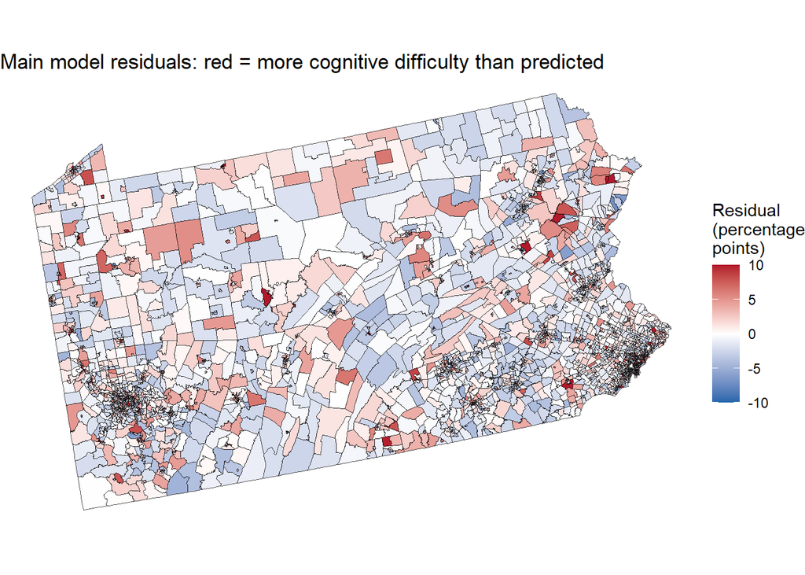

```r
analytic.sf |>
  mutate(resid = residuals(m.main)) |>
  ggplot() +
  geom_sf(aes(fill = resid), lwd = 0) +
  scale_fill_gradient2(name = "Residual\n(percentage\npoints)",
                       low = "#2166ac", mid = "white", high = "#b2182b",
                       limits = c(-10, 10), oob = scales::squish) +
  theme_void() +
  ggtitle("Main model residuals: red = more cognitive difficulty than predicted")
```

```r
# method = "Matrix" uses sparse matrix methods, which are much faster than the
# default eigenvalue method for ~3,400 tracts
sem <- errorsarlm(as.formula(main.formula), data = analytic.sp, listw = lw,
                  weights = pop.1864, zero.policy = TRUE, method = "Matrix")

sem.coef <- summary(sem)$Coef
sem.results <- tibble(term      = rownames(sem.coef),
                      estimate  = sem.coef[, 1],
                      std.error = sem.coef[, 2],
                      p.value   = sem.coef[, 4]) |>
  mutate(conf.low  = estimate - 1.96 * std.error,
         conf.high = estimate + 1.96 * std.error,
         model     = "Spatial error model")

sem.results |>
  mutate(across(where(is.numeric), \(x) signif(x, 3))) |>
  knitr::kable()
```

| term | estimate | std.error | p.value | conf.low | conf.high | model |
| --- | --- | --- | --- | --- | --- | --- |
| (Intercept) | 3.810000 | 0.81500 | 2.90e-06 | 2.21000 | 5.41000 | Spatial error model |
| water.statusTCE detected | -0.505000 | 0.30600 | 9.87e-02 | -1.10000 | 0.09450 | Spatial error model |
| water.statusNot monitored | 0.174000 | 0.21200 | 4.12e-01 | -0.24200 | 0.59000 | Spatial error model |
| log.npl.dist | 0.441000 | 0.19700 | 2.52e-02 | 0.05470 | 0.82600 | Spatial error model |
| log.airtox | 0.076500 | 0.21300 | 7.20e-01 | -0.34100 | 0.49400 | Spatial error model |
| pct.pov150 | 0.075500 | 0.00728 | 0.00e+00 | 0.06120 | 0.08970 | Spatial error model |
| pct.unemp | 0.078200 | 0.01590 | 9.00e-07 | 0.04690 | 0.10900 | Spatial error model |
| pct.nohs | 0.123000 | 0.01270 | 0.00e+00 | 0.09780 | 0.14800 | Spatial error model |
| pct.uninsured | -0.092400 | 0.01410 | 0.00e+00 | -0.12000 | -0.06470 | Spatial error model |
| income.10k | -0.199000 | 0.02570 | 0.00e+00 | -0.25000 | -0.14900 | Spatial error model |
| pct.minority | -0.000191 | 0.00400 | 9.62e-01 | -0.00803 | 0.00765 | Spatial error model |
| log.density | 0.190000 | 0.12000 | 1.13e-01 | -0.04470 | 0.42500 | Spatial error model |

```r
tibble(lambda   = sem$lambda,                 # spatial correlation of the errors
       AIC.ols  = AIC(m.main),
       AIC.sem  = AIC(sem)) |>
  knitr::kable(digits = 3)
```

| lambda | AIC.ols | AIC.sem |
| --- | --- | --- |
| 0.225 | 17696.23 | 17626.32 |

```r
# Residual clustering should be much weaker after the spatial error model
moran.test(residuals(sem), lw, zero.policy = TRUE)
```

```
    Moran I test under randomisation

data:  residuals(sem)
weights: lw

Moran I statistic standard deviate = -0.38413, p-value = 0.6496
alternative hypothesis: greater
sample estimates:
Moran I statistic       Expectation          Variance
    -0.0042962287     -0.0002961208      0.0001084408
```

### 4.5 Summary of exposure estimates across models

```r
exposure.summary <- bind_rows(sens.ols, keep_exposures(sem.results)) |>
  mutate(term = case_when(term == "water.statusTCE detected"  ~ "Water: TCE detected",
                          term == "water.statusNot monitored" ~ "Water: not monitored",
                          term == "log.npl.dist"              ~ "Superfund: log10 distance",
                          term == "log.airtox"                ~ "Air: log10 TCE"),
         model = factor(model, levels = c("Main model", "+ County fixed effects",
                                          "Without % uninsured", "Spatial error model")))

exposure.summary |>
  transmute(term, model,
            estimate = round(estimate, 3),
            ci = sprintf("(%.3f, %.3f)", conf.low, conf.high),
            p.value = signif(p.value, 2)) |>
  arrange(term, model) |>
  knitr::kable(col.names = c("Exposure", "Model", "Estimate", "95% CI", "p-value"))
```

| Exposure | Model | Estimate | 95% CI | p-value |
| --- | --- | --- | --- | --- |
| Air: log10 TCE | Main model | 0.191 | (-0.141, 0.522) | 0.260 |
| Air: log10 TCE | + County fixed effects | -0.362 | (-0.922, 0.198) | 0.210 |
| Air: log10 TCE | Without % uninsured | 0.221 | (-0.112, 0.555) | 0.190 |
| Air: log10 TCE | Spatial error model | 0.076 | (-0.341, 0.494) | 0.720 |
| Superfund: log10 distance | Main model | 0.379 | (0.056, 0.702) | 0.021 |
| Superfund: log10 distance | + County fixed effects | 0.070 | (-0.345, 0.486) | 0.740 |
| Superfund: log10 distance | Without % uninsured | 0.422 | (0.098, 0.747) | 0.011 |
| Superfund: log10 distance | Spatial error model | 0.441 | (0.055, 0.826) | 0.025 |
| Water: TCE detected | Main model | -0.528 | (-1.056, 0.001) | 0.050 |
| Water: TCE detected | + County fixed effects | -0.483 | (-1.055, 0.088) | 0.097 |
| Water: TCE detected | Without % uninsured | -0.504 | (-1.041, 0.034) | 0.067 |
| Water: TCE detected | Spatial error model | -0.505 | (-1.105, 0.094) | 0.099 |
| Water: not monitored | Main model | 0.132 | (-0.182, 0.446) | 0.410 |
| Water: not monitored | + County fixed effects | 0.170 | (-0.213, 0.554) | 0.380 |
| Water: not monitored | Without % uninsured | 0.164 | (-0.155, 0.482) | 0.310 |
| Water: not monitored | Spatial error model | 0.174 | (-0.242, 0.590) | 0.410 |

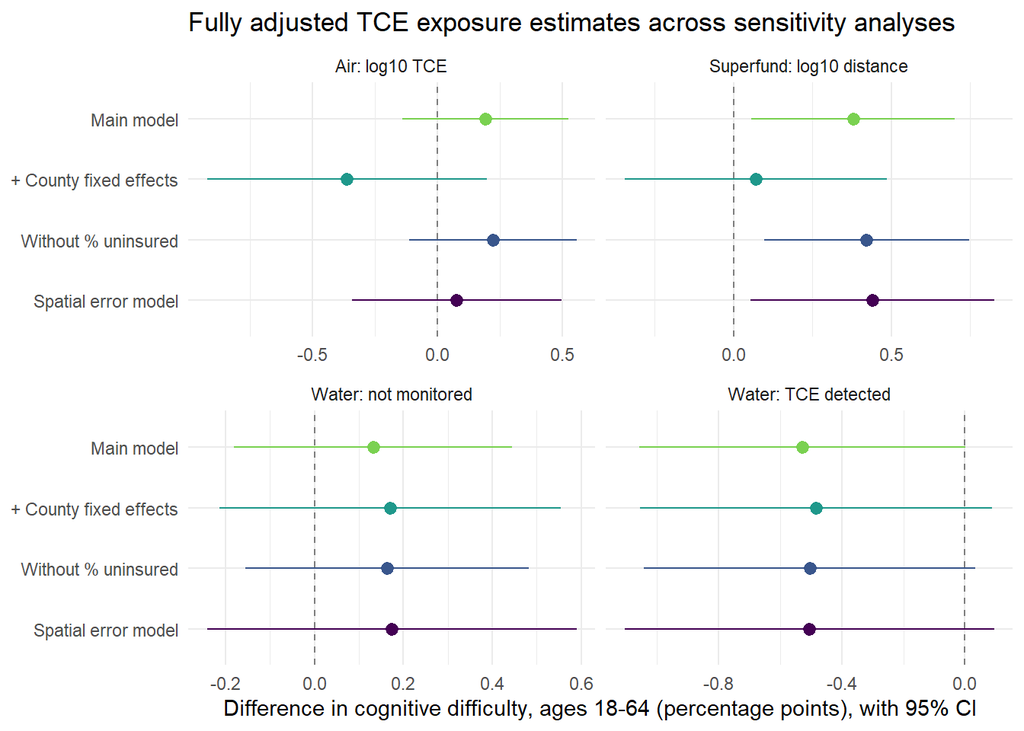

```r
exposure.summary |>
  mutate(model = fct_rev(model)) |>
  ggplot(aes(x = estimate, y = model, xmin = conf.low, xmax = conf.high, color = model)) +
  geom_vline(xintercept = 0, linetype = "dashed", color = "grey50") +
  geom_pointrange() +
  facet_wrap(~ term, scales = "free_x", ncol = 2) +
  scale_color_viridis_d(end = 0.8, guide = "none") +
  labs(x = "Difference in cognitive difficulty, ages 18-64 (percentage points), with 95% CI",
       y = NULL,
       title = "Fully adjusted TCE exposure estimates across sensitivity analyses") +
  theme_minimal()
```

### 4.6 Summary of findings

**Who is exposed.** TCE exposure was not evenly distributed. Tracts where TCE was detected at a nearby monitoring site were far more urban than monitored tracts without a detection (median 3,134 versus 78 people per km²), had a much larger share of racial and ethnic minority residents (33% versus 9%), and had more poverty (17.6% versus 14.1% below 150% of the poverty line) and unemployment. They were also closer to TCE Superfund sites and had higher modeled air concentrations, so the three exposure sources partly overlap. Tracts within 5 km of a TCE Superfund site were wealthier than tracts more than 10 km away (median household income $83,920 versus $66,471) but more diverse and densely populated, reflecting the concentration of sites in suburban southeast Pennsylvania. Cognitive difficulty was, if anything, lower in exposed tracts: 4.1% in both TCE-detected tracts and tracts within 5 km of a Superfund site, compared with 5.2% in tracts more than 10 km from a site.

**Crude associations were explained by social vulnerability.** In unadjusted models, tracts with a TCE detection had 0.97 percentage points more cognitive difficulty than monitored tracts without a detection. After adjusting for social vulnerability, this reversed to -0.45 percentage points, and to -0.51 after adding population density, with a confidence interval reaching zero. Each 10-fold increase in distance from a TCE Superfund site was associated with 0.96 percentage points more cognitive difficulty in the crude model and 0.45 after full adjustment, meaning tracts closer to sites had less cognitive difficulty, the opposite of the hypothesized direction. Modeled air TCE was not associated with cognitive difficulty in any model. The exposures alone explained less than 1% of the variation in cognitive difficulty, while the fully adjusted models explained about 37%, almost entirely through the social vulnerability measures, especially poverty, education, and income.

**The Superfund association reflects differences between counties.** Adding county fixed effects, which compares tracts only with other tracts in the same county, reduced the Superfund distance estimate from 0.38 to 0.07 percentage points (95% CI -0.35 to 0.49). The association therefore came from comparing counties with many TCE Superfund sites to counties far from any site, which differ in many ways the covariates do not capture. Within counties, distance to a site was not associated with cognitive difficulty. The water detection estimate was stable across all sensitivity analyses at about -0.5 percentage points but never clearly different from zero (p-values 0.05 to 0.10), and the air estimate remained null throughout. Removing percent uninsured, which had an unexpected negative coefficient likely because disability makes people eligible for public insurance, did not change any exposure estimate.

**Spatial dependence.** Cognitive difficulty was strongly spatially clustered (Moran’s I = 0.34). The covariates explained much of this clustering, but the main model’s residuals remained clustered (Moran’s I = 0.09, p < 0.001). A spatial error model (λ = 0.23) fit better than the ordinary model (AIC 17,626 versus 17,696) and removed the residual clustering (Moran’s I = -0.004, p = 0.65). Its exposure estimates were close to those of the main model, and it did not remove the Superfund association, because it accounts for similarity between neighboring tracts rather than broader differences between regions. Only the county fixed effects did.

**Overall.** Across water monitoring, Superfund proximity, and modeled air concentrations, there was no evidence that higher environmental TCE exposure was associated with higher rates of cognitive difficulty among adults aged 18-64 in Pennsylvania census tracts. Crude associations were explained by social vulnerability and regional differences. This is an ecological finding about tracts, not individuals: a broad self-reported outcome, patchy exposure data, and tract-level averaging could all hide an effect on the individuals most heavily exposed.

## 5 Conclusion

This project asked whether environmental exposure to trichloroethylene is associated with cognitive difficulty across Pennsylvania census tracts after accounting for social vulnerability. I built three tract-level exposure measures from public data, each reflecting a different pathway: detections at water monitoring sites from the Water Quality Portal, proximity to Superfund sites with TCE as a contaminant of concern, and modeled air concentrations from EPA’s 2020 AirToxScreen. None of the three showed the expected association. Tracts with more TCE exposure did not have higher rates of cognitive difficulty among adults aged 18-64, and the associations that appeared in unadjusted models were explained by social vulnerability and by differences between counties. The apparent link between Superfund proximity and lower cognitive difficulty disappeared once tracts were compared only with others in the same county, and accounting for spatial clustering did not change the conclusions.

The clearest finding concerns who is exposed rather than what exposure does. Tracts where TCE was detected in water were more urban, more racially and ethnically diverse, and had more poverty and unemployment than monitored tracts without a detection. Air exposure was concentrated around a small number of industrial facilities, mostly metal tube manufacturers, where nearly all of the modeled concentration came from stationary point sources. Superfund sites with TCE were concentrated in southeast Pennsylvania. This uneven distribution is itself an environmental justice concern, and it is also why careful adjustment mattered: without it, the analysis would have attributed differences in social and regional context to TCE.

These results should be read as an ecological, cross-sectional analysis with several important limitations:

- **Ecological design.** Associations between tracts do not describe individuals. A real effect on the most heavily exposed residents could be invisible in tract averages, especially when most residents of an “exposed” tract may have little exposure.
- **A broad outcome.** The ACS measure of cognitive difficulty is reported by one household member and covers many conditions, including developmental disability, mental illness, brain injury, and substance use. Any effect of TCE would be diluted by everything else the measure captures.
- **Sparse and preferential exposure data.** Water monitoring covered only about one in five tracts, sampling tends to cluster near suspected contamination, and only 62 monitoring sites ever detected TCE. Superfund sites were located by a single coordinate rather than their full footprint and plume, and distance is a crude proxy for vapor intrusion. AirToxScreen is a screening model for a single year, not a measurement.
- **Timing.** The exposure data span 2000 to 2020 and the outcome 2018 to 2022, but neurological effects may follow exposure by many years, and residents move. Current tract of residence may say little about lifetime exposure.
- **Residual confounding.** The county fixed effects showed how strongly regional context drives these associations, and unmeasured differences within counties could remain.

Despite these limitations, the analysis has several strengths. It combines three independent exposure sources covering different pathways, measures distance from where people live rather than from tract boundaries, restricts the outcome to working-age adults to reduce confounding by age, and tests its main findings against regional fixed effects, alternative covariate choices, and spatial dependence. The way the crude associations changed under these checks is itself informative about how geography and social vulnerability shape environmental health data.

The most important next step is moving from tracts to individuals. The tract-level exposure file built here can be linked to Penn Medicine BioBank participants by the BioBank’s data team, without revealing participant locations, to run a phenome-wide association study across diagnosed conditions. That would allow testing more specific outcomes with stronger prior evidence, such as Parkinson’s disease, dementia, and kidney cancer, using clinical diagnoses rather than self-report, and adjusting for individual characteristics. Further work at the tract level could examine specific health measures from CDC PLACES, incorporate residential history where available, and complete the remaining sensitivity analyses on non-detect handling, buffer distance, and ambient air concentrations.